# Assignment 1 - HISSS Game Visualization

We will be visualizing the states of the game HISSS in this assignment using `matplotlib` library. I will be visualizing the states of the game using two methods.

Before we begin, we will review the **50** cards available in the game. They are as follows :

- 6 heads
- 6 tails
- 36 mid-sections
- 2 wild cards

I will focus my visualization on one solution which leads to the *longest snake with no repeated body cards*. The length of that snake would be 8 cards and would consist of 8 rounds.

The visualization would show the cards *that are valid for the player to pick according to the current state of the game*. I am assuming that the player would pick only the cards that will lead to the desired snake. We will first show the visualization using the grid method.

# 1. Using grid method

The depiction is as follow:

- Triangles with a black dot represent *snake head*.
- Triangles without a black dot represent *snake tail*.
- Squares with two colors represent *snake body*.
- Multi-color triangle with a black dot represents *wildcard head*.
- Multi-color triangle without a black dot represents *wildcard tail*.

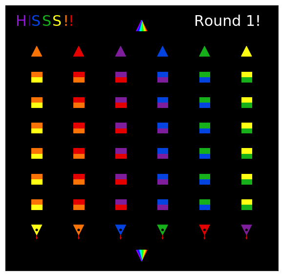

- We get yellow head snake.

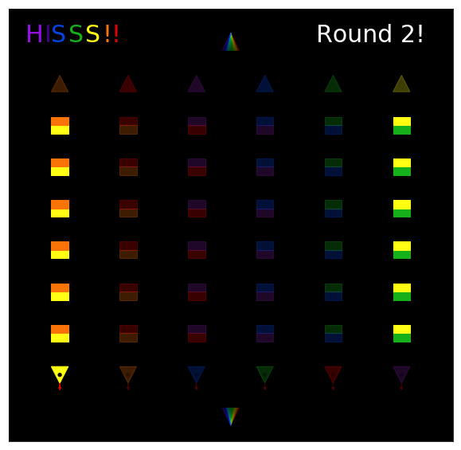

- We get yellow-orange body.

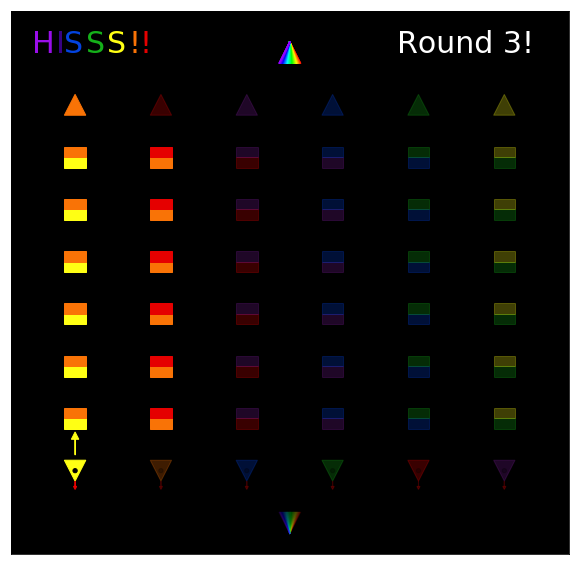

- We get orange-red body.

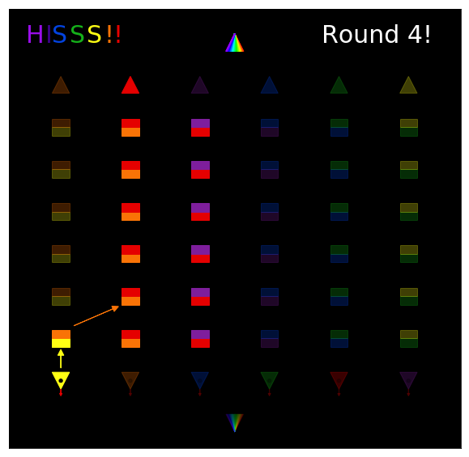

- We get red-purple body.

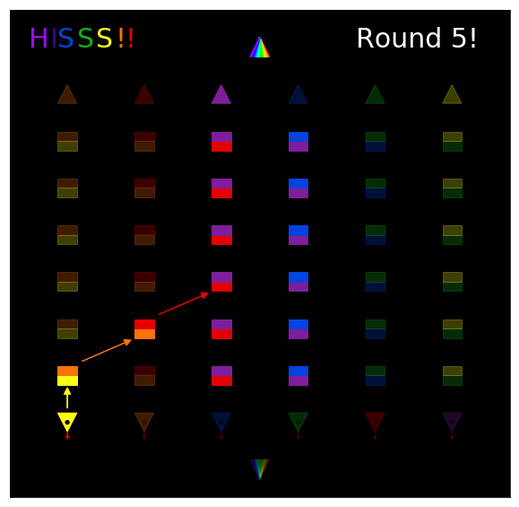

- We get purple-blue body.

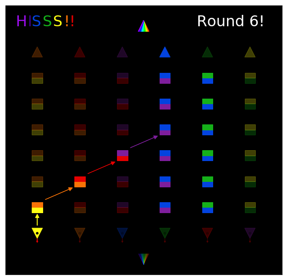

- We get blue-green body.

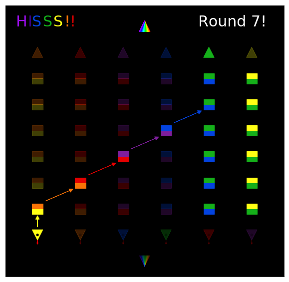

- We get green-yellow body.

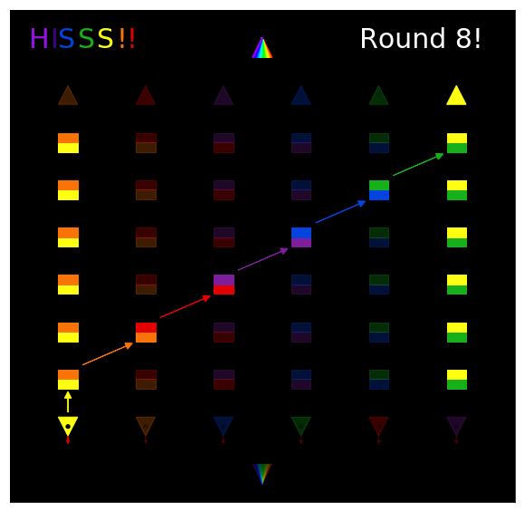

- We get yellow tail.

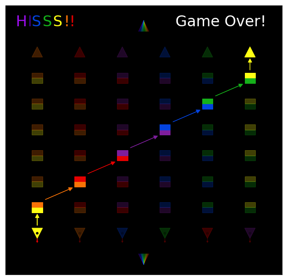

Now we will be simulating the same gameplay using the circular alignment method.

# 2. Using circular alignment method

The depiction is as follow:

- Circles with a black dot represent *snake head*.
- Circles without a black dot represent *snake tail*.
- Circles with two colors represent *snake body*.
- Multi-color circle with a black dot represents *wildcard head*.
- Multi-color circle without a black dot represents *wildcard tail*.

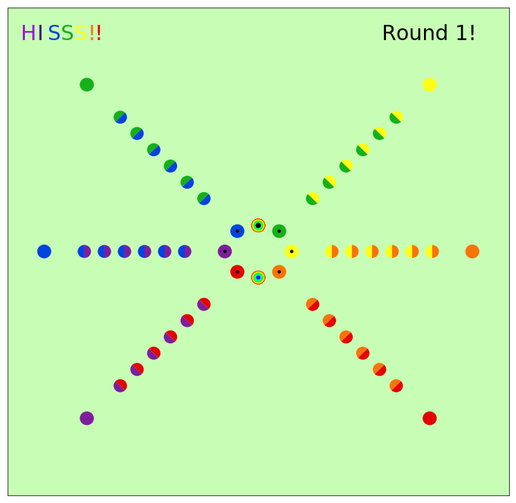

- We get yellow head snake.

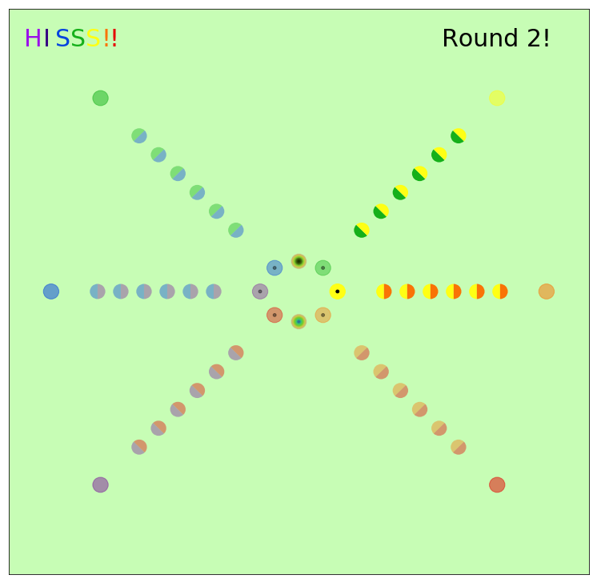

- We get yellow-orange body.

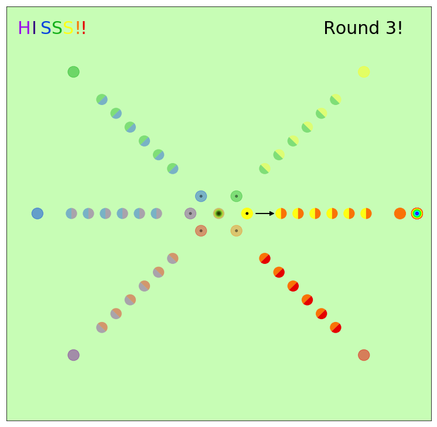

- We get orange-red body.

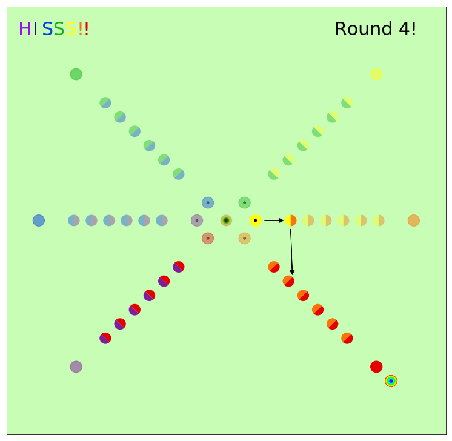

- We get red-purple body.

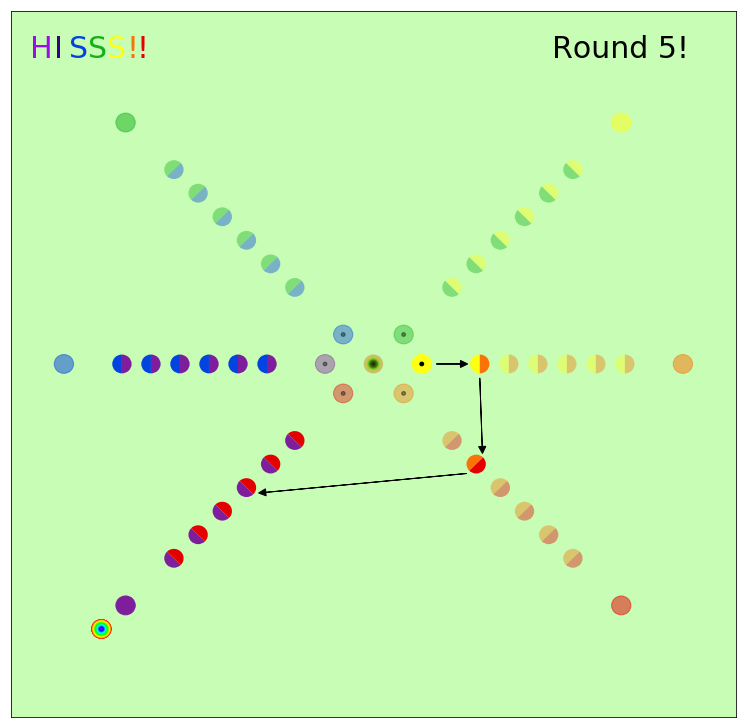

- We get purple-blue body.

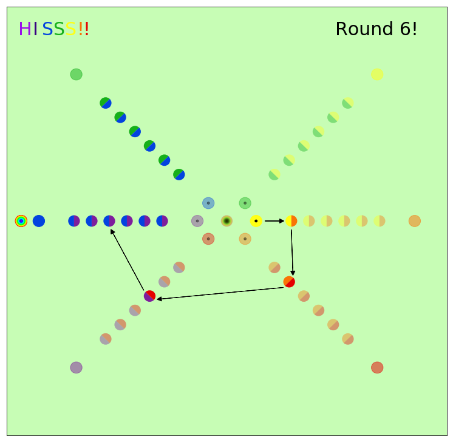

- We get blue-green body.

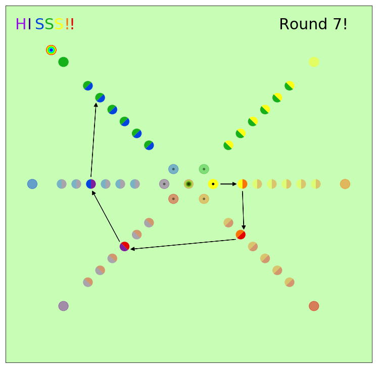

- We get green-yellow body.

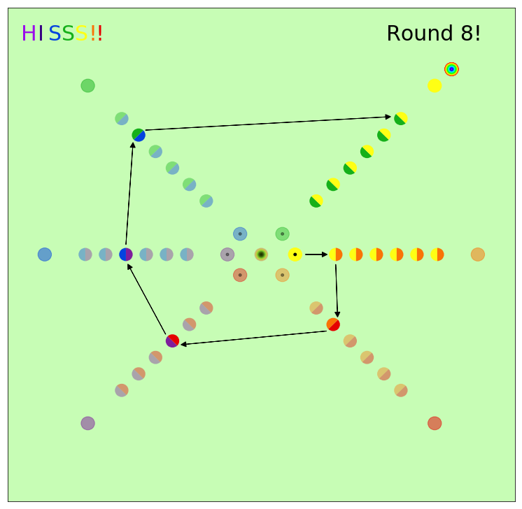

- We get yellow tail.

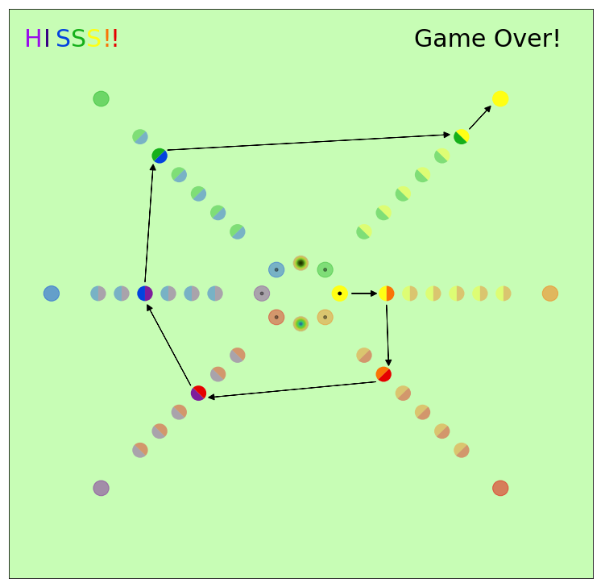

Both the visualization show **invalid cards** for the current state by *blurring* them and **valid cards** by *not blurring* them. The **arrows** shows the flow of gameplay till that round. The game ends when the player succeeds in creating a single snake.